# harold_floundering20180813

Harold Pollack

8/13/2018

This is Harold Pollack’s final assignment.

*Addendum–I submitted 8/12 at almost midnight PT–the deadline for the specific session. I then decided to push things back so that I could do things better. I had such difficulty with GitHub that I hadn’t gotten some of the basics nailed down.*

*Everything about cross-validation was updated after that initial submission. I have marked the points below in italics that are updated from the original for peer graders. Most important, I constructed a training and testing dataset from within the assigned training set to examine classifier performance.*

*I focused for prediction on the random forest classifier, since this was the most efficient. I divided the training set itself into a training, cross-validation, and test set, based on a 60-20-20 split, training on the 60% subsample only, and examining classifier performance on the cross-validation and testing sets. Cross-validation set performance helps us understand which classifier most accurately predicts exercise type in the data. Performance on the test segment helps us understand out-of-sample error.*

This assignment asked us to develop a classifier to distinguish five exercise modes, labeled A-E, as practiced by six identified users. The training set contained 19,622 examples and some 189 variables. We then were asked to predict exercise modes within a test set of 20 examples. *The random forest classifier performed extremely well. Its accuracy was roughly 94% in all three groups–far more accurate than any other classifier employed, even on the full training set alone.*

As the sociologists say, there is a manifest and a latent function to this assignment. The manifest function is to demonstrate understanding of ML methods to produce reasonable classifiers in these data. The latent functions are to properly execute many mundane aspects of R coding to handle and process the dataset, and to navigate the frustrating aspects of posting the results. Within the available time constraints, I learned a lot, but have a decent way to go on both aspects.

Much of what I learned was mundane, such as how to label basic cross-tabs using the expss package. All are important.I wish I had more time to explore the methodological aspects of the assignment.

I learned much doing this assignment. My hesitancy to commit says much about my relationship with GitHub. Ironically, the mechanics of GitHub and basic R programming provided greater challenges than the specific ML methods. I also experienced many odd mechanical problems, including challenges getting plots to post.

I mainly used the assignment as an opportunity to investigate several classifiers. Three are presented here: (1) one-vs-all logistic regression classifiers; (2) classification trees, (3) support vector machines, and (4) random forest. *I omit the one vs. all classifier here, which was the least accurate of the classifiers I explored.* I explored linear discriminant analysis. Results for thse are also omitted in the present document. *I did experiment with majority voting, finding some improvement in accuracy within the training set. I ran out of time at the deadline in properly exploring these results. The high accuracy of RF also made these other methods seem less essential for this particular application.*

On the substance, each of the classifiers provided insight. As noted below, random forest provided by far the most accurate fit within the training set. SVM with a nonlinear kernel also performed well.

Unfortunately, one fairly uninteresting factor variable—which was a timestamp—was by far the most important in predicting exercise mode. *(now fixed) If I had greater time, I would have implemented a cross-validation set to properly explore related over-fitting issues.* **Random forest’s 94% accurate fit within both the cross-validation and test test somewhat obviated the need for this exercise.**

## loading required libraries

Let’s load required libraries, including expss, which makes nice cross-tabs.

```r
library("caret", lib.loc="/Library/Frameworks/R.framework/Versions/3.4/Resources/library")
library("dbplyr", lib.loc="/Library/Frameworks/R.framework/Versions/3.4/Resources/library")
library("e1071", lib.loc="/Library/Frameworks/R.framework/Versions/3.4/Resources/library")
library("gbm", lib.loc="/Library/Frameworks/R.framework/Versions/3.4/Resources/library")
library("Hmisc", lib.loc="/Library/Frameworks/R.framework/Versions/3.4/Resources/library")
library("ISLR", lib.loc="/Library/Frameworks/R.framework/Versions/3.4/Resources/library")
library("randomForest", lib.loc="/Library/Frameworks/R.framework/Versions/3.4/Resources/library")
library("rpart", lib.loc="/Library/Frameworks/R.framework/Versions/3.4/Resources/library")
library("rpart.plot", lib.loc="/Library/Frameworks/R.framework/Versions/3.4/Resources/library")
library("tidyverse", lib.loc="/Library/Frameworks/R.framework/Versions/3.4/Resources/library")
library(kernlab)
##
## expss allows cross-tabs with readable labels
##
## install.packages("expss")
library(expss)
```

## load training and testing datasets.

Here are also some cross-tabs to understand the basic data. Shows is the distribution of the posited dependent variable classe. I also showed the cross-tab with individual users.

```r
pml_training <- read.csv("pml-training.csv")
pml_testing <- read.csv("pml-testing.csv")
table(pml_training$classe)
```

```
##
##    A    B    C    D    E
## 5580 3797 3422 3216 3607
```

```r
table(pml_training$classe,pml_training$user_name)
```

```
##
##     adelmo carlitos charles eurico jeremy pedro
##   A   1165      834     899    865   1177   640
##   B    776      690     745    592    489   505
##   C    750      493     539    489    652   499
##   D    515      486     642    582    522   469
##   E    686      609     711    542    562   497
```

```r
pml_training$named_classe <- paste("workout type ",pml_training$classe)
table(pml_training$named_classe)
```

```
##
## workout type  A workout type  B workout type  C workout type  D
##            5580            3797            3422            3216
## workout type  E
##            3607
```

## Now set up classe dummies for one vs all, time dummies, and the rest

```
##
##   adelmo carlitos  charles   eurico   jeremy    pedro
##     3892     3112     3536     3070     3402     2610
```

```r
splitSample <- sample(1:3, size=nrow(pml_training), prob=c(0.6,0.2,.2), replace = TRUE)
HAP_training_set <- pml_training[splitSample==1,]
HAP_cv_set <- pml_training[splitSample==2,]
HAP_testing_set <- pml_training[splitSample==3,]
dim(HAP_training_set)
```

```
## [1] 11806   194
```

```r
dim(HAP_cv_set)
```

```
## [1] 3927  194
```

```r
dim(HAP_testing_set)
```

```
## [1] 3889  194
```

## Random Forest

Thsi pattern is reflected in the dominance of the time stamp in the variable importance plot. The roll, pitch, and yaw of the dumbbell, as well as the total acceleration of the belt were also predictive.

```
##                  MeanDecreaseGini
## roll_dumbbell            898.6207
## pitch_dumbbell           669.9073
## yaw_dumbbell             740.0510
## total_accel_belt         744.5443
## gyros_arm_x              514.9830
## gyros_arm_y              492.2133
## gyros_arm_z              307.0294
## magnet_forearm_x         600.9034
## magnet_forearm_y         526.6270
## magnet_forearm_z         662.0826
## user_name                392.9262
## cvtd_timestamp.f        2780.6539
```

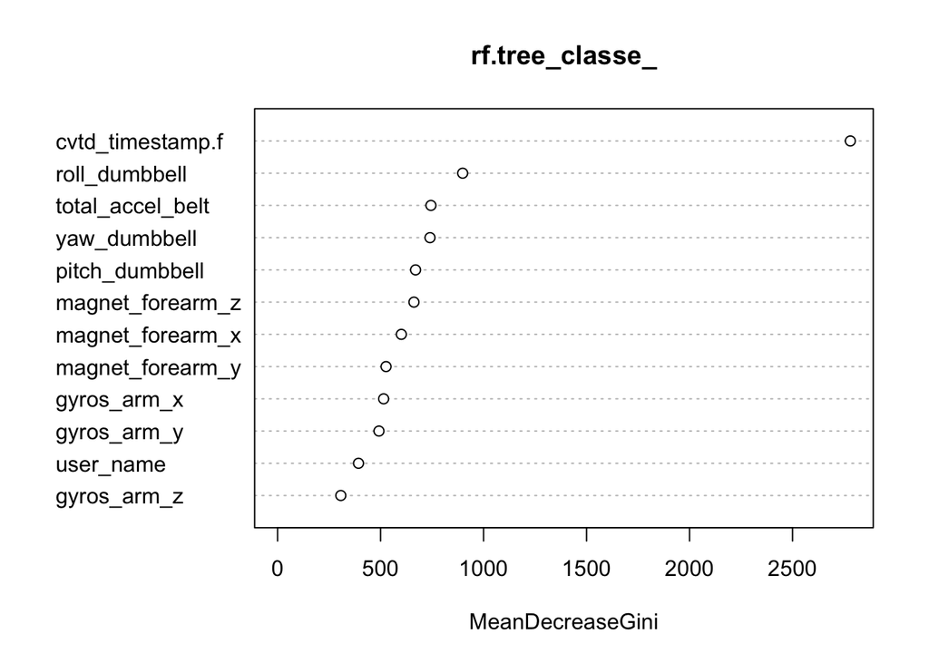

```
## pred_classe_rf
##    A    B    C    D    E
## 3395 2277 2140 1882 2112
```

## one vs all classifier

Now I implemented a one vs. all classifier, just to see how it would perform, and because the Logit coefficients are readily interpreted. Results not reported here.

## Classification trees–complete with cool diagram.

One interesting aspect here was that I had originally coded the timestamp as a series of dummy variables. The resulting classifier was notably worse for both random forest and the classification tree. The dummy structure did not take advantage of the logical interconnections between these dummies in forming the trees. Of course the classification tree report is pretty opaque compared with the rpart.plot.

```
## n= 11806
##
## node), split, n, loss, yval, (yprob)
##       * denotes terminal node
##
##   1) root 11806 8456 A (0.28 0.2 0.18 0.16 0.18)
##     2) cvtd_timestamp.f=02/12/2011 13:32,02/12/2011 13:33,02/12/2011 13:34,02/12/2011 14:56,02/12/2011 14:57,05/12/2011 11:23,05/12/2011 11:24,05/12/2011 14:22,05/12/2011 14:23,28/11/2011 14:13,28/11/2011 14:14,30/11/2011 17:10,30/11/2011 17:11 7507 4157 A (0.45 0.3 0.21 0.044 0)
##       4) cvtd_timestamp.f=02/12/2011 13:32,02/12/2011 13:33,02/12/2011 14:56,05/12/2011 11:23,05/12/2011 14:22,28/11/2011 14:13,30/11/2011 17:10 2312  205 A (0.91 0.089 0 0 0) *
##       5) cvtd_timestamp.f=02/12/2011 13:34,02/12/2011 14:57,05/12/2011 11:24,05/12/2011 14:23,28/11/2011 14:14,30/11/2011 17:11 5195 3112 B (0.24 0.4 0.3 0.063 0)
##        10) cvtd_timestamp.f=02/12/2011 14:57,05/12/2011 11:24 1794  921 B (0.46 0.49 0.057 0 0)
##          20) magnet_forearm_z>=176.5 1578  766 A (0.51 0.42 0.065 0 0)
##            40) gyros_arm_x< 2.13 1320  539 A (0.59 0.36 0.046 0 0) *
##            41) gyros_arm_x>=2.13 258   72 B (0.12 0.72 0.16 0 0) *
##          21) magnet_forearm_z< 176.5 216    7 B (0.028 0.97 0.0046 0 0) *
##        11) cvtd_timestamp.f=02/12/2011 13:34,05/12/2011 14:23,28/11/2011 14:14,30/11/2011 17:11 3401 1963 C (0.12 0.36 0.42 0.096 0)
##          22) yaw_dumbbell>=-73.15452 2033 1027 B (0.14 0.49 0.31 0.055 0) *
##          23) yaw_dumbbell< -73.15452 1368  565 C (0.11 0.15 0.59 0.16 0) *
##     3) cvtd_timestamp.f=02/12/2011 13:35,02/12/2011 14:58,02/12/2011 14:59,05/12/2011 11:25,05/12/2011 14:24,28/11/2011 14:15,30/11/2011 17:12 4299 2164 E (0 0.0042 0.13 0.37 0.5)
##       6) roll_dumbbell< -94.85151 745  279 C (0 0.0027 0.63 0.052 0.32)
##        12) cvtd_timestamp.f=02/12/2011 14:58,05/12/2011 11:25 578  112 C (0 0.0035 0.81 0.067 0.12) *
##        13) cvtd_timestamp.f=02/12/2011 14:59,05/12/2011 14:24 167    0 E (0 0 0 0 1) *
##       7) roll_dumbbell>=-94.85151 3554 1657 E (0 0.0045 0.024 0.44 0.53)
##        14) total_accel_belt< 20.5 3071 1516 D (0 0.0052 0.028 0.51 0.46)
##          28) magnet_forearm_x< -170 2394  956 D (0 0.0038 0.033 0.6 0.36)
##            56) cvtd_timestamp.f=02/12/2011 13:35,02/12/2011 14:58,05/12/2011 11:25,05/12/2011 14:24,30/11/2011 17:12 2143  749 D (0 0.0042 0.036 0.65 0.31)
##             112) gyros_arm_y>=-1.42 1984  601 D (0 0.0045 0.039 0.7 0.26) *
##             113) gyros_arm_y< -1.42 159   11 E (0 0 0 0.069 0.93) *
##            57) cvtd_timestamp.f=02/12/2011 14:59,28/11/2011 14:15 251   44 E (0 0 0 0.18 0.82) *
##          29) magnet_forearm_x>=-170 677  131 E (0 0.01 0.01 0.17 0.81) *
##        15) total_accel_belt>=20.5 483    1 E (0 0 0 0.0021 1) *
```

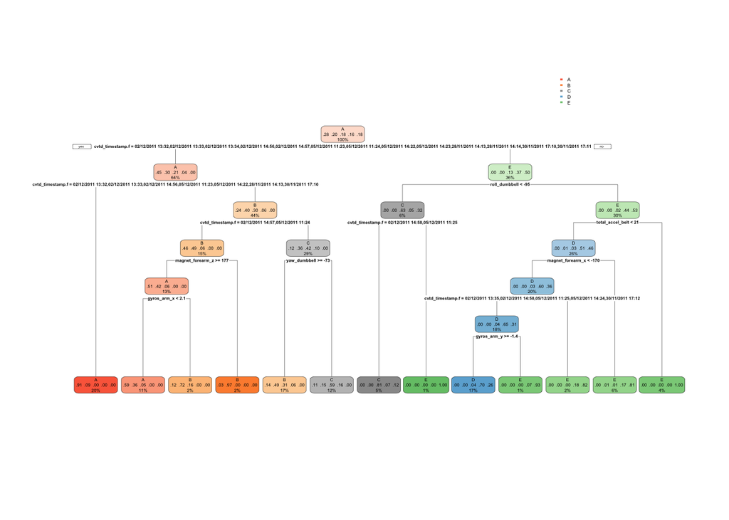

```
## pred_classe4_rpart_training
##    A    B    C    D    E
## 3632 2507 1946 1984 1737
```

```
##
## pred_classe4_rpart_training    A    B    C    D    E
##                           A 2888  683   61    0    0
##                           B  317 1401  677  112    0
##                           C  145  206 1269  255   71
##                           D    0    9   78 1383  514
##                           E    0    7    7  173 1550
```

```
##
## pred_classe4_rpart_testing   A   B   C   D   E
##                          A 918 211  20   0   0
##                          B 113 446 194  45   0
##                          C  55  69 421  90  23
##                          D   0   6  29 467 182
##                          E   0   1   0  79 520
```

```
## pred_classe4_rpart_testing
##    A    B    C    D    E
## 1149  798  658  684  600
```

```
##
## pred_classe4_rpart_cv   A   B   C   D   E
##                     A 990 218  21   0   0
##                     B 111 457 230  41   0
##                     C  43  80 396  87  30
##                     D   0   2  18 426 190
##                     E   0   1   1  58 527
```

```
## pred_classe4_rpart_cv
##    A    B    C    D    E
## 1229  839  636  636  587
```

## Support vector machines with radial, poly, and linear kernels.

*I explored various kernels with the SVM classifier, to see which performed well or poorly.* As you can see below, the poly and radial kernals provided notably more accurate performance in the training set than did the linear kernel.Yet even within the training set, SVM was less accurate than the random forest’s performance on the cross-validation and testing sets.

```
##
##        A    B    C    D    E
##   0  362  556  513  311  627
##   1  266  227  204  158  154
##   2  791  977  623  564  785
##   3 1931  546  752  890  569
```

# Now let’s show some labelled comparisons of the classifiers

|  | #Total |
| --- | --- |
| Accuracy of RF classifier in cv set |  |
| 0 | 5.3 |
| 1 | 94.7 |
| #Total cases | 3927 |

|  | #Total |
| --- | --- |
| Accuracy of RF classifier in training set |  |
| 0 | 5.9 |
| 1 | 94.1 |
| #Total cases | 11806 |

|  | #Total |
| --- | --- |
| Accuracy of RF classifier in HAP_testing set |  |
| 0 | 5.5 |
| 1 | 94.5 |
| #Total cases | 3889 |

Note how powerfully the time-stamp predicts outcomes. Then let’s print out some crosstabs for the RPART classification tree. Let’s also examine when it differs from the random forest. Note that the random forest is accurate to about 94% in the training, cross-validation, and testing set, suggesting that overfitting does not explain its high accuracy.

```r
cro_cpct(pml_training$classe,pml_training$cvtd_timestamp)
```

|  | Time stamp 02/12/2011 13:32 | Time stamp 02/12/2011 13:33 | Time stamp 02/12/2011 13:34 | Time stamp 02/12/2011 13:35 | Time stamp 02/12/2011 14:56 | Time stamp 02/12/2011 14:57 | Time stamp 02/12/2011 14:58 | Time stamp 02/12/2011 14:59 | Time stamp 05/12/2011 11:23 | Time stamp 05/12/2011 11:24 | Time stamp 05/12/2011 11:25 | Time stamp 05/12/2011 14:22 | Time stamp 05/12/2011 14:23 | Time stamp 05/12/2011 14:24 | Time stamp 28/11/2011 14:13 | Time stamp 28/11/2011 14:14 | Time stamp 28/11/2011 14:15 | Time stamp 30/11/2011 17:10 | Time stamp 30/11/2011 17:11 | Time stamp 30/11/2011 17:12 |
| --- | --- | --- | --- | --- | --- | --- | --- | --- | --- | --- | --- | --- | --- | --- | --- | --- | --- | --- | --- | --- |
| workout type–ground truth in training set |  |  |  |  |  |  |  |  |  |  |  |  |  |  |  |  |  |  |  |  |
| A | 100 | 74.8 |  |  | 100 | 48.1 |  |  | 100 | 43.0 |  | 100 | 27.2 |  | 100 | 2.1 |  | 100 | 21.4 |  |
| B |  | 25.2 | 32.2 |  |  | 51.9 | 2.1 |  |  | 46.1 |  |  | 36.9 |  |  | 39.5 |  |  | 34.0 |  |
| C |  |  | 54.5 |  |  |  | 39.5 |  |  | 10.9 | 23.2 |  | 35.9 | 0.7 |  | 32.6 |  |  | 44.7 | 0.8 |
| D |  |  | 13.2 | 32.7 |  |  | 47.1 |  |  |  | 34.1 |  |  | 48.2 |  | 25.7 | 26.7 |  |  | 47.8 |
| E |  |  |  | 67.3 |  |  | 11.3 | 100 |  |  | 42.7 |  |  | 51.1 |  |  | 73.3 |  |  | 51.4 |
| #Total cases | 177 | 1321 | 1375 | 1019 | 235 | 1380 | 1364 | 557 | 190 | 1497 | 1425 | 267 | 1370 | 973 | 833 | 1498 | 739 | 869 | 1440 | 1093 |

```r
cro_cpct(HAP_training_set$pred_classe4_rpart_training)
```

|  | #Total |
| --- | --- |
| RPART predicted workout type |  |
| A | 30.8 |
| B | 21.2 |
| C | 16.5 |
| D | 16.8 |
| E | 14.7 |
| #Total cases | 11806 |

```r
cro_cpct(HAP_training_set$pred_classe4_rpart_training,HAP_training_set$named_classe)
```

|  | workout type–ground truth in training set workout type A | workout type–ground truth in training set workout type B | workout type–ground truth in training set workout type C | workout type–ground truth in training set workout type D | workout type–ground truth in training set workout type E |
| --- | --- | --- | --- | --- | --- |
| RPART predicted workout type |  |  |  |  |  |
| A | 86.2 | 29.6 | 2.9 |  |  |
| B | 9.5 | 60.8 | 32.4 | 5.8 |  |
| C | 4.3 | 8.9 | 60.7 | 13.3 | 3.3 |
| D |  | 0.4 | 3.7 | 71.9 | 24.1 |
| E |  | 0.3 | 0.3 | 9.0 | 72.6 |
| #Total cases | 3350 | 2306 | 2092 | 1923 | 2135 |

```r
cro_cpct(HAP_training_set$pred_classe4_rpart_training,HAP_training_set$pred_classe_rf)
```

|  | RF training prediction A | RF training prediction B | RF training prediction C | RF training prediction D | RF training prediction E |
| --- | --- | --- | --- | --- | --- |
| RPART predicted workout type |  |  |  |  |  |
| A | 86.3 | 28.2 | 2.8 |  |  |
| B | 9.3 | 63.4 | 30.1 | 5.5 |  |
| C | 4.4 | 7.8 | 63.3 | 10.5 | 3.2 |
| D |  | 0.3 | 3.5 | 75.0 | 23.3 |
| E |  | 0.3 | 0.3 | 9.0 | 73.5 |
| #Total cases | 3395 | 2277 | 2140 | 1882 | 2112 |

Now let’s print out some tables for the support vector machine with different kernels. There are really two main points here. First, the linear kernel is notably less accurate–and less time-consuming to estimate–than the polynomial or radial kernels. The polynomial and radial predictions were also highly correlated with each other. Second, each classifier is far less accurate than the random forest. Indeed, they are far less accurate within the training set than the random forest classifier is out of sample.

```r
cro_cpct(HAP_training_set$predicted_svm_classe_radial,HAP_training_set$named_classe)
```

|  | workout type–ground truth in training set workout type A | workout type–ground truth in training set workout type B | workout type–ground truth in training set workout type C | workout type–ground truth in training set workout type D | workout type–ground truth in training set workout type E |
| --- | --- | --- | --- | --- | --- |
| SVM prediction–radial kernel |  |  |  |  |  |
| A | 80.6 | 13.0 | 14.8 | 8.6 | 6.0 |
| B | 3.8 | 70.1 | 5.9 | 3.0 | 9.4 |
| C | 6.5 | 8.8 | 68.1 | 9.0 | 7.0 |
| D | 8.6 | 5.8 | 10.7 | 76.9 | 10.9 |
| E | 0.6 | 2.3 | 0.4 | 2.5 | 66.7 |
| #Total cases | 3350 | 2306 | 2092 | 1923 | 2135 |

```r
cro_cpct(HAP_training_set$predicted_svm_classe_poly,HAP_training_set$named_classe)
```

|  | workout type–ground truth in training set workout type A | workout type–ground truth in training set workout type B | workout type–ground truth in training set workout type C | workout type–ground truth in training set workout type D | workout type–ground truth in training set workout type E |
| --- | --- | --- | --- | --- | --- |
| SVM prediction–polynomial kernel |  |  |  |  |  |
| A | 82.1 | 14.3 | 17.0 | 9.3 | 8.8 |
| B | 3.2 | 68.0 | 4.4 | 3.5 | 8.5 |
| C | 6.2 | 9.5 | 68.4 | 8.7 | 7.5 |
| D | 7.9 | 5.7 | 9.9 | 76.1 | 11.0 |
| E | 0.6 | 2.6 | 0.3 | 2.4 | 64.3 |
| #Total cases | 3350 | 2306 | 2092 | 1923 | 2135 |

```r
cro_cpct(HAP_training_set$predicted_svm_classe_linear,HAP_training_set$named_classe)
```

|  | workout type–ground truth in training set workout type A | workout type–ground truth in training set workout type B | workout type–ground truth in training set workout type C | workout type–ground truth in training set workout type D | workout type–ground truth in training set workout type E |
| --- | --- | --- | --- | --- | --- |
| SVM prediction–linear kernel |  |  |  |  |  |
| A | 65.4 | 35.3 | 37.0 | 21.6 | 29.9 |
| B | 10.2 | 27.5 | 4.7 | 9.0 | 13.4 |
| C | 9.6 | 15.4 | 40.7 | 10.3 | 10.2 |
| D | 14.4 | 19.2 | 17.2 | 52.7 | 16.7 |
| E | 0.3 | 2.7 | 0.4 | 6.3 | 29.7 |
| #Total cases | 3350 | 2306 | 2092 | 1923 | 2135 |

```r
cro_cpct(HAP_training_set$d_accuracy_linear)
```

|  | #Total |
| --- | --- |
| Accuracy of SVM linear kernel |  |
| 0 | 54.9 |
| 1 | 45.1 |
| #Total cases | 11806 |

```r
cro_cpct(HAP_training_set$d_accuracy_poly)
```

|  | #Total |
| --- | --- |
| Accuracy of SVM polynomial kernel |  |
| 0 | 27.3 |
| 1 | 72.7 |
| #Total cases | 11806 |

```r
cro_cpct(HAP_training_set$d_accuracy_radial)
```

|  | #Total |
| --- | --- |
| Accuracy of SVM radial kernel |  |
| 0 | 26.8 |
| 1 | 73.2 |
| #Total cases | 11806 |

```r
cro_cpct(HAP_training_set$d_accuracy_linear,HAP_training_set$d_accuracy_radial)
```

|  | Accuracy of SVM radial kernel 0 | Accuracy of SVM radial kernel 1 |
| --- | --- | --- |
| Accuracy of SVM linear kernel |  |  |
| 0 | 83.5 | 44.4 |
| 1 | 16.5 | 55.6 |
| #Total cases | 3164 | 8642 |

```r
cro_cpct(HAP_training_set$d_accuracy_poly,HAP_training_set$d_accuracy_radial)
```

|  | Accuracy of SVM radial kernel 0 | Accuracy of SVM radial kernel 1 |
| --- | --- | --- |
| Accuracy of SVM polynomial kernel |  |  |
| 0 | 87.8 | 5.1 |
| 1 | 12.2 | 94.9 |
| #Total cases | 3164 | 8642 |

```r
cro_cpct(HAP_training_set$predicted_svm_classe_radial,HAP_training_set$predicted_svm_classe_poly)
```

|  | SVM prediction–polynomial kernel A | SVM prediction–polynomial kernel B | SVM prediction–polynomial kernel C | SVM prediction–polynomial kernel D | SVM prediction–polynomial kernel E |
| --- | --- | --- | --- | --- | --- |
| SVM prediction–radial kernel |  |  |  |  |  |
| A | 90.1 | 2.4 | 3.7 | 1.8 | 0.5 |
| B | 3.0 | 92.2 | 3.1 | 1.1 | 3.7 |
| C | 3.5 | 1.3 | 89.3 | 2.3 | 0.7 |
| D | 2.3 | 1.9 | 2.7 | 93.1 | 2.1 |
| E | 1.2 | 2.2 | 1.2 | 1.7 | 93.0 |
| #Total cases | 3800 | 2018 | 2182 | 2301 | 1505 |

```r
cro_cpct(HAP_training_set$predicted_svm_classe_radial,HAP_training_set$predicted_svm_classe_linear)
```

|  | SVM prediction–linear kernel A | SVM prediction–linear kernel B | SVM prediction–linear kernel C | SVM prediction–linear kernel D | SVM prediction–linear kernel E |
| --- | --- | --- | --- | --- | --- |
| SVM prediction–radial kernel |  |  |  |  |  |
| A | 52.1 | 23.4 | 16.1 | 14.8 | 2.2 |
| B | 15.6 | 45.8 | 15.6 | 11.0 | 8.6 |
| C | 16.1 | 6.3 | 53.3 | 9.4 | 1.0 |
| D | 8.3 | 11.2 | 7.7 | 57.4 | 13.4 |
| E | 7.9 | 13.3 | 7.3 | 7.5 | 74.9 |
| #Total cases | 4834 | 1536 | 1943 | 2657 | 836 |

```r
HAP_training_set$num_accurate<-HAP_training_set$d_accuracy_linear+HAP_training_set$d_accuracy_poly+HAP_training_set$d_accuracy_radial
cro_cpct(HAP_training_set$num_accurate)
```

[output not shown]

```r
cro_cpct(HAP_training_set$pred_classe_rf,HAP_training_set$named_classe)
```

|  | workout type–ground truth in training set workout type A | workout type–ground truth in training set workout type B | workout type–ground truth in training set workout type C | workout type–ground truth in training set workout type D | workout type–ground truth in training set workout type E |
| --- | --- | --- | --- | --- | --- |
| RF training prediction |  |  |  |  |  |
| A | 95.8 | 6.3 | 1.9 |  |  |
| B | 2.7 | 90.5 | 4.4 | 0.4 |  |
| C | 1.5 | 3.1 | 92.2 | 4.2 | 0.4 |
| D |  | 0.1 | 1.3 | 93.8 | 2.3 |
| E |  |  | 0.2 | 1.7 | 97.2 |
| #Total cases | 3350 | 2306 | 2092 | 1923 | 2135 |

```r
cro_cpct(HAP_training_set$predicted_svm_classe_radial,HAP_training_set$pred_classe_rf)
```

|  | RF training prediction A | RF training prediction B | RF training prediction C | RF training prediction D | RF training prediction E |
| --- | --- | --- | --- | --- | --- |
| SVM prediction–radial kernel |  |  |  |  |  |
| A | 81.2 | 9.7 | 15.5 | 8.8 | 6.0 |
| B | 3.4 | 73.7 | 3.6 | 3.0 | 9.4 |
| C | 6.5 | 7.9 | 70.2 | 6.7 | 6.8 |
| D | 8.5 | 6.0 | 10.4 | 79.0 | 10.5 |
| E | 0.5 | 2.7 | 0.3 | 2.4 | 67.3 |
| #Total cases | 3395 | 2277 | 2140 | 1882 | 2112 |

```r
cro_cpct(HAP_training_set$pred_classe_rf,HAP_training_set$named_classe)
```

|  | workout type–ground truth in training set workout type A | workout type–ground truth in training set workout type B | workout type–ground truth in training set workout type C | workout type–ground truth in training set workout type D | workout type–ground truth in training set workout type E |
| --- | --- | --- | --- | --- | --- |
| RF training prediction |  |  |  |  |  |
| A | 95.8 | 6.3 | 1.9 |  |  |
| B | 2.7 | 90.5 | 4.4 | 0.4 |  |
| C | 1.5 | 3.1 | 92.2 | 4.2 | 0.4 |
| D |  | 0.1 | 1.3 | 93.8 | 2.3 |
| E |  |  | 0.2 | 1.7 | 97.2 |
| #Total cases | 3350 | 2306 | 2092 | 1923 | 2135 |

The 1 vs all classifier–Outout suppressed